# Data_journalism_project_MCU_&_Diversity_Code

Matamoros_Carolina

19 de mayo de 2018

### 1. Purpose of the Project

This is the final data project for the “Web Data Collection and Social Media Mining”. In it multiple inputs are required aside of the blog entry that answers the project’s question. This markdown file aims to be a replicable tool for future researchers who wish to further analyse the topic of this project.

**Proyect’s topic:** Gender and Race Diversity in the Marvel Cinematic Universe

**Research question:** Does the overall reception of the MCU improves if the cast and characters potray a more diverse population (In terms of race and gender)?

**Method:** Several web pages are to be scrapped in order to obtain the data required to answer the research question, following you can find which ones where targeted and the reasoning behind the selection.

*To measure the reception of the movies two main data sources were collected.

```
1. **box office:** https://www.the-numbers.com/movies/franchise/Marvel-Cinematic-Universe#tab=summary
2. **rating and score:** https://www.rottentomatoes.com/franchise/marvel_cinematic_universe
```

*To measure the diversity of the cast and characters of the movies

```
3.**structure:** (Cast & Characters): http://marvelcinematicuniverse.wikia.com/wiki/Marvel_Cinematic_Universe
```

## Data from 1.Box Office: The Numbers and the MCU money maker

```r
#Data from 1.**box office:** https://www.the-numbers.com/movies/franchise/Marvel-Cinematic-Universe#tab=summary

# construct list of urls

BoxOfficeMCU_Url <- "https://www.the-numbers.com/movies/franchise/Marvel-Cinematic-Universe#tab=summary"
BoxOffice_enR <- read_html(BoxOfficeMCU_Url)

GeneralNumbersTable <- html_table(html_nodes(BoxOffice_enR, xpath = '//table'), header = TRUE, fill = TRUE)

GeneralBoxTable <- as.data.frame(GeneralNumbersTable[1])
GeneralBoxTable <- GeneralBoxTable[-c(20, 21, 22, 23, 24), ]
GeneralBoxTable <- GeneralBoxTable[c(2,3,4,5,6,1)]

MovieNames <- GeneralBoxTable[1:19,"Movie"]
MovieNames <- str_replace_all(MovieNames," ","-")
MovieNames2 <- str_replace_all(MovieNames,":","")
MovieNames2[2] <- "Incredible-Hulk-The"
MovieNames2[6] <- "Avengers-The-(2012)"
MovieNames2[14] <-"Doctor-Strange-(2016)"

BaseMovieurl1 <- "http://www.the-numbers.com/movie/"
BaseMovieurl2 <- "#tab=box-office"
BaseMovieurl3 <-"#tab=international"

Url_MoviesUS <- paste0(BaseMovieurl1, MovieNames2,BaseMovieurl2)
Url_MoviesWorld <- paste0(BaseMovieurl1, MovieNames2,BaseMovieurl3)

BoxOffice_enR <- read_html(BoxOfficeMCU_Url)

listBox <- list()

for (i in 1:length(Url_MoviesUS)) {

  tryCatch({

    listBox[i]<- html_table(html_nodes(read_html(Url_MoviesUS[i]), xpath = '//*[@id="box_office_chart"]/table'), header = TRUE, fill = TRUE)[2]

  }, error=function(e){cat("ERROR :",conditionMessage(e), "\n")})

}

names(listBox) <- MovieNames

str(GeneralBoxTable)
```

```
## 'data.frame':    21 obs. of  6 variables:
##  $ Movie                 : chr  "Iron Man" "The Incredible Hulk" "Iron Man 2" "Thor" ...
##  $ ProductionBudget      : chr  "$186,000,000" "$137,500,000" "$170,000,000" "$150,000,000" ...
##  $ DomesticOpeningWeekend: chr  "$102,118,668" "$55,414,050" "$128,122,480" "$65,723,338" ...
##  $ DomesticBox.Office    : chr  "$318,604,126" "$134,806,913" "$312,433,331" "$181,030,624" ...
##  $ WorldwideBox.Office   : chr  "$585,171,547" "$265,573,859" "$621,156,389" "$449,326,618" ...
##  $ Release.Date          : chr  "May 2, 2008" "Jun 13, 2008" "May 7, 2010" "May 6, 2011" ...
```

```r
str(listBox)
```

```
## List of 19
##  $ Iron-Man                           :'data.frame': 155 obs. of  8 variables:
##   ..$ Date       : chr [1:155] "2008/05/02" "2008/05/03" "2008/05/04" "2008/05/05" ...
##   ..$ Rank       : chr [1:155] "1" "1" "1" "1" ...
##   ..$ Gross      : chr [1:155] "$38,734,361" "$37,350,099" "$26,034,208" "$6,934,568" ...
##   ..$ % Change   : chr [1:155] "" "-4%" "-30%" "-73%" ...
##   ..$ Theaters   : chr [1:155] "4,105" "4,105" "4,105" "4,105" ...
##   ..$ Per Theater: chr [1:155] "$9,436" "$9,099" "$6,342" "$1,689" ...
##   ..$ Total Gross: chr [1:155] "$38,734,361" "$76,084,460" "$102,118,668" "$109,053,236" ...
##   ..$ Days       : int [1:155] 1 2 3 4 5 6 7 8 9 10 ...
##  $ The-Incredible-Hulk                :'data.frame': 66 obs. of  8 variables:
##   ..$ Date       : chr [1:66] "2008/06/13" "2008/06/14" "2008/06/15" "2008/06/16" ...
##   ..$ Rank       : chr [1:66] "1" "1" "1" "1" ...
##   ..$ Gross      : chr [1:66] "$21,468,125" "$18,383,725" "$15,562,200" "$6,010,405" ...
##   ..$ % Change   : chr [1:66] "" "-14%" "-15%" "-61%" ...
##   ..$ Theaters   : chr [1:66] "3,505" "3,505" "3,505" "3,505" ...
##   ..$ Per Theater: chr [1:66] "$6,125" "$5,245" "$4,440" "$1,715" ...
##   ..$ Total Gross: chr [1:66] "$21,468,125" "$39,851,850" "$55,414,050" "$61,424,455" ...
##   ..$ Days       : int [1:66] 1 2 3 4 5 6 7 8 9 10 ...
##  $ Iron-Man-2                         :'data.frame': 105 obs. of  8 variables:
##   ..$ Date       : chr [1:105] "2010/05/07" "2010/05/08" "2010/05/09" "2010/05/10" ...
##   ..$ Rank       : chr [1:105] "1" "1" "1" "1" ...
##   ..$ Gross      : chr [1:105] "$51,239,677" "$45,776,170" "$31,106,633" "$9,366,982" ...
##   ..$ % Change   : chr [1:105] "" "-11%" "-32%" "-70%" ...
##   ..$ Theaters   : chr [1:105] "4,380" "4,380" "4,380" "4,380" ...
##   ..$ Per Theater: chr [1:105] "$11,699" "$10,451" "$7,102" "$2,139" ...
##   ..$ Total Gross: chr [1:105] "$51,239,677" "$97,015,847" "$128,122,480" "$137,489,462" ...
##   ..$ Days       : int [1:105] 1 2 3 4 5 6 7 8 9 10 ...
##  $ Thor                               :'data.frame': 112 obs. of  8 variables:
##   ..$ Date       : chr [1:112] "2011/05/06" "2011/05/07" "2011/05/08" "2011/05/09" ...
##   ..$ Rank       : chr [1:112] "1" "1" "1" "1" ...
##   ..$ Gross      : chr [1:112] "$25,481,796" "$23,341,263" "$16,900,279" "$5,403,057" ...
##   ..$ % Change   : chr [1:112] "" "-8%" "-28%" "-68%" ...
##   ..$ Theaters   : chr [1:112] "3,955" "3,955" "3,955" "3,955" ...
##   ..$ Per Theater: chr [1:112] "$6,443" "$5,902" "$4,273" "$1,366" ...
##   ..$ Total Gross: chr [1:112] "$25,481,796" "$48,823,059" "$65,723,338" "$71,126,395" ...
##   ..$ Days       : int [1:112] 1 2 3 4 5 6 7 8 9 10 ...
##  $ Captain-America:-The-First-Avenger :'data.frame': 112 obs. of  8 variables:
##   ..$ Date       : chr [1:112] "2011/07/22" "2011/07/23" "2011/07/24" "2011/07/25" ...
##   ..$ Rank       : chr [1:112] "1" "1" "1" "1" ...
```

[output cut: 117 more lines]

```
##   ..$ Gross      : chr [1:94] "$75,941,146" "$65,995,366" "$60,067,439" "$40,151,729" ...
##   ..$ % Change   : chr [1:94] "" "-13%" "-9%" "-33%" ...
##   ..$ Theaters   : chr [1:94] "4,020" "4,020" "4,020" "4,020" ...
##   ..$ Per Theater: chr [1:94] "$18,891" "$16,417" "$14,942" "$9,988" ...
##   ..$ Total Gross: chr [1:94] "$75,941,146" "$141,936,512" "$202,003,951" "$242,155,680" ...
##   ..$ Days       : int [1:94] 1 2 3 4 5 6 7 8 9 10 ...
##  $ Avengers:-Infinity-War             :'data.frame': 24 obs. of  8 variables:
##   ..$ Date       : chr [1:24] "2018/04/27" "2018/04/28" "2018/04/29" "2018/04/30" ...
##   ..$ Rank       : int [1:24] 1 1 1 1 1 1 1 1 1 1 ...
##   ..$ Gross      : chr [1:24] "$106,334,939" "$82,131,612" "$69,231,632" "$24,740,117" ...
##   ..$ % Change   : chr [1:24] "" "-23%" "-16%" "-64%" ...
##   ..$ Theaters   : chr [1:24] "4,474" "4,474" "4,474" "4,474" ...
##   ..$ Per Theater: chr [1:24] "$23,767" "$18,358" "$15,474" "$5,530" ...
##   ..$ Total Gross: chr [1:24] "$106,334,939" "$188,466,551" "$257,698,183" "$282,438,300" ...
##   ..$ Days       : int [1:24] 1 2 3 4 5 6 7 8 9 10 ...
```

## Data from 2.rating and score: Rotten Tomatoes and the MCU scores

```r
xpath1 <- '//div[@data-franchise-type="movie"]//a'

MCU_ROttenTommatoes_Url <- "https://www.rottentomatoes.com/franchise/marvel_cinematic_universe"
MCU_Ratings_enR <- read_html(MCU_ROttenTommatoes_Url)

Text1 <- str_flatten(html_text(html_nodes(MCU_Ratings_enR, xpath = xpath1 )), collapse = "" ) %>% str_trim()
Text1 <- str_split(Text1, "\\n", simplify = TRUE) %>% str_trim()
Text1 <- Text1[2:length(Text1)]

Href1 <- unique(html_nodes(MCU_Ratings_enR, xpath = xpath1 )%>% html_attr("href"))

xpath2 <- '//div[@data-franchise-type="movie"]//span[@class="meter-value"]'

Text2 <- str_flatten(html_text(html_nodes(MCU_Ratings_enR, xpath = xpath2 )), collapse = "" ) %>% str_trim()
Text2 <- str_split(Text2, "\\n", simplify = TRUE) %>% str_trim()
Text2 <- Text2[3:length(Text2)]
Text2 <- str_split(str_flatten(Text2, collapse = ""),"%", simplify = TRUE) %>% str_trim()
Text2 <- Text2[1:length(Text2)-1]

is.even <- function(x){ x %% 2 == 0 }

n <- 0
k <- 0
PopCorn <- as.double()
Tomatoes <- as.double()

for (i in 1:length(Text2)){

  if(is.even(i)){
  n <- n +1
  PopCorn[n]<- as.numeric(Text2[i])

  } else {
  k <- k+1
  Tomatoes[k] <- as.numeric(Text2[i])

  }


}


Text1[5] <- "Guardians of the Galaxy Vol 2"
Text1[14] <- "The Avengers"


RottenResults <- cbind.data.frame(Text1,Tomatoes,PopCorn)

names(RottenResults)[1] <- "Movie"

Overall <- left_join(GeneralBoxTable,RottenResults, by = "Movie")
str(RottenResults)
```

```
## 'data.frame':    19 obs. of  3 variables:
##  $ Movie   : Factor w/ 19 levels "Ant-Man","Avengers: Age of Ultron",..: 3 4 18 14 10 8 5 1 2 9 ...
##  $ Tomatoes: num  84 97 92 92 83 89 91 82 75 91 ...
##  $ PopCorn : num  91 79 87 88 88 86 89 86 83 92 ...
```

```r
str(Overall)
```

```
## 'data.frame':    21 obs. of  8 variables:
##  $ Movie                 : chr  "Iron Man" "The Incredible Hulk" "Iron Man 2" "Thor" ...
##  $ ProductionBudget      : chr  "$186,000,000" "$137,500,000" "$170,000,000" "$150,000,000" ...
##  $ DomesticOpeningWeekend: chr  "$102,118,668" "$55,414,050" "$128,122,480" "$65,723,338" ...
##  $ DomesticBox.Office    : chr  "$318,604,126" "$134,806,913" "$312,433,331" "$181,030,624" ...
##  $ WorldwideBox.Office   : chr  "$585,171,547" "$265,573,859" "$621,156,389" "$449,326,618" ...
##  $ Release.Date          : chr  "May 2, 2008" "Jun 13, 2008" "May 7, 2010" "May 6, 2011" ...
##  $ Tomatoes              : num  94 67 73 77 79 92 80 66 89 91 ...
##  $ PopCorn               : num  91 71 72 76 74 91 78 77 92 92 ...
```

## Data from 3.structure: For Cast & Characters per movie:

```r
MCU_Wiki_Url <- "http://marvelcinematicuniverse.wikia.com/wiki/Marvel_Cinematic_Universe"
MCU_wiki_enR <- read_html(MCU_Wiki_Url)


xpath2 <- '//span[contains(text(), "Phase One")]/following::a[@data-tracking="custom-level-3"]'

Text3 <- html_text(html_nodes(MCU_wiki_enR, xpath = xpath2 )) %>% str_trim()
Text3 <- Text3[1:length(Text1)]
Href2 <- unique(html_nodes(MCU_wiki_enR, xpath = xpath2 )%>% html_attr("href"))
Href2 <- Href2[1:length(Text1)]

MCUwikishort <- "http://marvelcinematicuniverse.wikia.com"

MCUWikisURls <- paste0(MCUwikishort,Href2)


xpath3 <- '//*[@id="mw-content-text"]/ul[1]/li/a'
html_text(html_nodes(read_html(MCUWikisURls[8]), xpath = xpath3))
```

```
##  [1] "Chris Hemsworth"              "Thor"
##  [3] "Natalie Portman"              "Jane Foster"
##  [5] "Tom Hiddleston"               "Loki"
##  [7] "Anthony Hopkins"              "Odin"
##  [9] "Christopher Eccleston"        "Malekith"
## [11] "Jaimie Alexander"             "Sif"
## [13] "Zachary Levi"                 "Fandral"
## [15] "Ray Stevenson"                "Volstagg"
## [17] "Tadanobu Asano"               "Hogun"
## [19] "Idris Elba"                   "Heimdall"
## [21] "Rene Russo"                   "Frigga"
## [23] "Adewale Akinnuoye-Agbaje"     "Algrim / Kurse"
## [25] "Kat Dennings"                 "Darcy Lewis"
## [27] "Stellan Skarsgård"            "Erik Selvig"
## [29] "Alice Krige"                  "Eir"
```

[output cut: 17 more lines]

```r
xpath4 <- '//span[@id="Appearances"]/following::a'

listCastCharacters <- list()
HrefCharacters <- list()

for (i in 1:length(Text3)) {

  tryCatch({

    listCastCharacters[[i]]<- html_text(html_nodes(read_html(MCUWikisURls[i]), xpath = xpath3))
    HrefCharacters[[i]] <- unique(html_nodes(read_html(MCUWikisURls[i]), xpath = xpath3 )%>% html_attr("href"))


  }, error=function(e){cat("ERROR :",conditionMessage(e), "\n")})

}


for (i in 1:length(Text3)) {
  HrefCharacters[[i]] <- paste0(MCUwikishort,HrefCharacters[[i]])
}

names(listCastCharacters) <- Text3
names(HrefCharacters) <- Text3

str(listCastCharacters[[1]])
```

```
##  chr [1:57] "Robert Downey, Jr." "Tony Stark/Iron Man" ...
```

```r
df_charcast <- function(x){
  df1 <- data.frame()
  df2 <- data.frame()
  df <- data.frame()

  if(!is.even(length(x))){
    x <- c(x,"Empty")
  }

    df1<- as.character(x[c(seq(1, length(x)-1, by=2))])
    df2<- as.character(x[c(seq(2, length(x), by=2))])

  for (i in 1:length(df1)){

    df[i,1]<- df1[i]
    df[i,2]<- df2[i]
  }

    names(df) <- c("Cast","Character")
    df
}

listCharacterDF <- list()
k <- as.double()

for (i in 1:length(Text3)){

  listCharacterDF[[i]]<- df_charcast(listCastCharacters[[i]])

  k <- nrow(listCharacterDF[[i]])-5

  listCharacterDF[[i]]<- listCharacterDF[[i]][1:k,]


}


listHrefDF <- list()

for (i in 1:length(Text3)){

  listHrefDF[[i]]<- df_charcast(HrefCharacters[[i]])

  k <- nrow(listHrefDF[[i]])-5

  listHrefDF[[i]]<- listHrefDF[[i]][1:k,]

}

for (i in 1:length(Text3)){

  names(listHrefDF[[i]])[1]<- "Cast_URL"
  names(listHrefDF[[i]])[2]<- "Character_URL"

}




for (i in 1:length(Text3)){

  while(nrow(listCharacterDF[[i]])!= nrow(listHrefDF[[i]])){

    if (nrow(listCharacterDF[[i]]) > nrow(listHrefDF[[i]])){

      listHrefDF[[i]] <- rbind(listHrefDF[[i]],c("Empty","Empty"))

    }else if(nrow(listCharacterDF[[i]]) < nrow(listHrefDF[[i]])) {

      listCharacterDF[[i]] <- rbind(listCharacterDF[[i]],c("Empty","Empty"))

    }
  }


  listCharacterDF[[i]]<- cbind2(listCharacterDF[[i]],listHrefDF[[i]])
}


names(listCharacterDF) <- Text3


dataChar <- data.frame()
for (i in 1:length(Text3)){

  if(i == 1){
  dataChar <- listCharacterDF[[i]]
  } else {
  dataChar <- rbind(dataChar,listCharacterDF[[i]])
  }
}

dataChar <- unique(dataChar, by = "Cast")
dataChar <- cbind(dataChar,basename(dataChar[,4]))
names(dataChar)[5] <- "FileName"
dataChar <-dataChar[c(5,1,2,3,4)]


#folder for the character info

 folder <- "Characters_htmls/"
 dir.create(folder)
 CharFiles <- paste0(basename(dataChar[,5]),".html")

 for (i in 1:nrow(dataChar)) {

   if (!file.exists(paste0(folder, CharFiles[i]))) {

     tryCatch({

       download.file(dataChar[i,5], destfile = paste0(folder, CharFiles[i]))

       Sys.sleep(runif(1, 0, 1))

     }, error=function(e){cat("ERROR :",conditionMessage(e), "\n")})
   }
 }
```

[output not shown]

```r
 list_files <- list.files(folder)

 list_files_path <-  list.files(folder, full.names = TRUE)

 length(list_files)
```

```
## [1] 345
```

```r
 # import pages and extract content

 real_name <- character()
 gender <- character()
 citizenship <- character()
 species <- character()
 age <- character()

 xpath_name <- "//aside//*[contains(text(), 'Real Name')]/following::div"
 xpath_gender <- "//aside//*[contains(text(), 'Gender')]/following::div"
 xpath_citizenship <- "//aside//*[contains(text(), 'Citizenship')]/following::a"
 xpath_species <- "//aside//*[contains(text(), 'Species')]/following::a"
 xpath_age <- "//aside//*[contains(text(), 'Age')]/following::div"

 for (i in 1:length(list_files_path)) {
   real_name[i] <-  html_text(html_nodes(read_html(list_files_path[i]), xpath = xpath_name))[1]
   gender[i] <-  html_text(html_nodes(read_html(list_files_path[i]), xpath = xpath_gender))[1]
   citizenship[i] <-  html_text(html_nodes(read_html(list_files_path[i]), xpath = xpath_citizenship))[1]
   species[i] <- html_text(html_nodes(read_html(list_files_path[i]), xpath = xpath_species))[1]
   age[i]    <- html_text(html_nodes(read_html(list_files_path[i]), xpath = xpath_age))[1]

 }
 Characters <- data.frame()

 Characters <- cbind(real_name,gender,citizenship,species,age,str_remove(list_files,".html"))

 Characters <- as.data.frame(Characters)
 names(Characters)[6] <- "FileName"

 Characters <- inner_join(Characters, dataChar, by = "FileName")
 Characters <- inner_join(na.omit(Characters[1]), Characters, by = "real_name")

 Characters <- subset(Characters,!duplicated(Characters$real_name))

 #Some aggregated Values of interest

 a <- as.data.frame(table(Characters$species))
 #speciesoverall <- subset(a, a$Var1=="Human", select=Freq)/nrow(Characters)
 speciesoverall <- cbind(a, a$Freq/nrow(Characters))
 speciesoverall
```

```
##              Var1 Freq a$Freq/nrow(Characters)
## 1     Achernonian    1             0.003846154
## 2         Android    1             0.003846154
## 3       Asgardian   11             0.042307692
## 4       Celestial    1             0.003846154
## 5      Centaurian    1             0.003846154
## 6        Dark Elf    2             0.007692308
## 7             Dog    1             0.003846154
## 8           Dwarf    1             0.003846154
## 9  Flora colossus    1             0.003846154
## 10    Frost Giant    5             0.019230769
## 11    Halfworlder    1             0.003846154
## 12          Human  204             0.784615385
## 13     Hurctarian    1             0.003846154
## 14           Kree    2             0.007692308
## 15         Kronan    1             0.003846154
## 16      Krylorian    3             0.011538462
## 17      Luphomoid    1             0.003846154
## 18   October 2014    1             0.003846154
## 19      Sovereign    1             0.003846154
## 20          Titan    1             0.003846154
## 21          Vanir    1             0.003846154
## 22      Xandarian    3             0.011538462
## 23      Zehoberei    1             0.003846154
```

```r
 a <- as.data.frame(table(Characters$gender))
 genderoverall <- cbind(a, a$Freq/nrow(Characters))
 genderoverall
```

```
##                                   Var1 Freq a$Freq/nrow(Characters)
## 1                               Female   69             0.265384615
## 2                                 Male  189             0.726923077
## 3 Male (masculine programming & voice)    1             0.003846154
```

```r
 a <- as.data.frame(table(Characters$citizenship))
 citizenshipoverall <- cbind(a, a$Freq/nrow(Characters))
 citizenshipoverall
```

```
##             Var1 Freq a$Freq/nrow(Characters)
## 1         Afghan    6             0.023076923
## 2       American  145             0.557692308
## 3      Asgardian   11             0.042307692
## 4        Belgian    1             0.003846154
## 5      Brazilian    1             0.003846154
## 6        British   11             0.042307692
## 7        Chinese    3             0.011538462
## 8         French    4             0.015384615
## 9         German    1             0.003846154
## 10        Indian    1             0.003846154
## 11         Jotun    5             0.019230769
## 12 Kree Imperial    2             0.007692308
## 13       Mexican    3             0.011538462
## 14   Nazi German    6             0.023076923
## 15     Norwegian    2             0.007692308
## 16 Nova Imperial    3             0.011538462
## 17       Russian    3             0.011538462
## 18      Sakaaran    2             0.007692308
## 19      Sokovian    3             0.011538462
## 20 South African    1             0.003846154
## 21     Sovereign    1             0.003846154
## 22        Soviet    4             0.015384615
## 23    Svartálfar    2             0.007692308
## 24         Vanir    1             0.003846154
## 25      Wakandan   11             0.042307692
```

```r
temp <- as.character()
 for (i in 1:length(Text3)){

   for (j in 1:nrow(listCharacterDF[[i]])){
   temp[j] <- basename(listCharacterDF[[i]][j,ncol(listCharacterDF[[i]])])
   }
   listCharacterDF[[i]]<- cbind2(listCharacterDF[[i]],temp)
   #listCharacterDF[[i]]<- listCharacterDF[[i]][,1:4]
   temp <- as.character()
   names(listCharacterDF[[i]])[5] <- "FileName"
 }


temp <- data.frame()
for (i in 1:length(Text3)){

  temp <- left_join(listCharacterDF[[i]], Characters, by = "FileName")
  temp <- inner_join(na.omit(temp[6]), temp, by = "real_name")
  listCharacterDF[[i]] <- temp
  temp <- data.frame()
}
```

[output not shown]

```r
speciestemp <- as.double()
gendertemp <- as.double()
citizentemp <- as.double()

for (i in 1:length(Text3)){

    a <- as.data.frame(table(listCharacterDF[[i]]["species"]))
    speciestemp[i] <- subset(a, a$Var1=="Human", select=Freq)/nrow(listCharacterDF[[i]])

    a <- as.data.frame(table(listCharacterDF[[i]]["gender"]))
    gendertemp[i] <- subset(a, a$Var1=="Female", select=Freq)/nrow(listCharacterDF[[i]])

    a <- as.data.frame(table(listCharacterDF[[i]]["citizenship"]))
    citizentemp[i] <- subset(a, a$Var1=="American", select=Freq)/nrow(listCharacterDF[[i]])

}

names(speciestemp) <- "species"
names(gendertemp) <- "gender"
names(citizentemp) <- "citizenship"

speciestemp <- data.frame(matrix(unlist(speciestemp), nrow=length(Text3), byrow=T),stringsAsFactors=FALSE)
gendertemp <- data.frame(matrix(unlist(gendertemp), nrow=length(Text3), byrow=T),stringsAsFactors=FALSE)
citizentemp <- data.frame(matrix(unlist(citizentemp), nrow=length(Text3), byrow=T),stringsAsFactors=FALSE)

Text3[15] <- "Guardians of the Galaxy Vol 2"

speciestemp <- cbind(Text3,speciestemp,stringsAsFactors=FALSE)
gendertemp <- cbind(Text3,gendertemp,stringsAsFactors=FALSE)
citizentemp <- cbind(Text3,citizentemp,stringsAsFactors=FALSE)


names(speciestemp)[1] <- "Movie"
names(gendertemp)[1] <- "Movie"
names(citizentemp)[1] <- "Movie"

names(speciestemp)[2] <- "% Human"
names(gendertemp)[2] <- "% Female"
names(citizentemp)[2] <- "% American"

temp <- data.frame()
temp <- left_join(gendertemp, citizentemp, by = "Movie",stringsAsFactors=FALSE)
temp <- left_join(temp, speciestemp, by = "Movie",stringsAsFactors=FALSE)

Overall <- left_join(Overall,temp, by = "Movie")
str(Overall)
```

```
## 'data.frame':    21 obs. of  11 variables:
##  $ Movie                 : chr  "Iron Man" "The Incredible Hulk" "Iron Man 2" "Thor" ...
##  $ ProductionBudget      : chr  "$186,000,000" "$137,500,000" "$170,000,000" "$150,000,000" ...
##  $ DomesticOpeningWeekend: chr  "$102,118,668" "$55,414,050" "$128,122,480" "$65,723,338" ...
##  $ DomesticBox.Office    : chr  "$318,604,126" "$134,806,913" "$312,433,331" "$181,030,624" ...
##  $ WorldwideBox.Office   : chr  "$585,171,547" "$265,573,859" "$621,156,389" "$449,326,618" ...
##  $ Release.Date          : chr  "May 2, 2008" "Jun 13, 2008" "May 7, 2010" "May 6, 2011" ...
##  $ Tomatoes              : num  94 67 73 77 79 92 80 66 89 91 ...
##  $ PopCorn               : num  91 71 72 76 74 91 78 77 92 92 ...
##  $ % Female              : num  0.211 0.3 0.364 0.208 0.167 ...
##  $ % American            : num  0.684 0.8 0.727 0.417 0.583 ...
##  $ % Human               : num  1 1 1 0.458 1 ...
```

## Data report and ploting

```r
#Data Preáration

a<- as.numeric()
for (i in 1:nrow(Overall)){

  a[i] <- str_remove_all(Overall[i,2],",")%>% str_trim()
  a[i] <- as.numeric(str_extract_all(a[i],"[[:digit:]]+")%>% str_trim())

}

Overall[,2]<- as.numeric(a)

b<- as.numeric()
for (i in 1:nrow(Overall)){

  b[i] <- str_remove_all(Overall[i,3],",")%>% str_trim()
  b[i] <- as.numeric(str_extract_all(b[i],"[[:digit:]]+")%>% str_trim())

}
Overall[,3]<- as.numeric(b)

c<- as.numeric()
for (i in 1:nrow(Overall)){

  c[i] <- str_remove_all(Overall[i,4],",")%>% str_trim()
  c[i] <- as.numeric(str_extract_all(c[i],"[[:digit:]]+")%>% str_trim())

}
Overall[,4]<- as.numeric(c)

d<- as.numeric()
for (i in 1:nrow(Overall)){

  d[i] <- str_remove_all(Overall[i,5],",")%>% str_trim()
  d[i] <- as.numeric(str_extract_all(d[i],"[[:digit:]]+")%>% str_trim())

}

Overall[,5]<- as.numeric(d)

e <- date()
ey<- as.numeric()
em<- as.numeric()
ed<- as.numeric()
for (i in 1:nrow(Overall)){

  ey[i] <- as.numeric(str_extract_all(Overall[i,6],"\\d{4}")%>% str_trim())
  em[i] <- as.numeric(match(str_extract_all(Overall[i,6],"[:alpha:]{3}")%>% str_trim(),month.abb))
  ed[i] <- as.numeric(str_extract(Overall[i,6],"[:digit:]+")%>% str_trim())
  e[i] <- paste0(ey[i],"-",em[i],"-",ed[i])
}
Overall[,6]<- as.Date(e)

Overall2 <- Overall[1:19,]
Overall2[rev(order(as.Date(Overall2$Release.Date))),]
```

```
##                                  Movie ProductionBudget
## 19              Avengers: Infinity War        300000000
## 18                       Black Panther        200000000
## 17                      Thor: Ragnarok        180000000
## 16              Spider-Man: Homecoming        175000000
## 15       Guardians of the Galaxy Vol 2        200000000
## 14                      Doctor Strange        165000000
## 13          Captain America: Civil War        250000000
## 12                             Ant-Man        130000000
## 11             Avengers: Age of Ultron        330600000
## 10             Guardians of the Galaxy        170000000
## 9  Captain America: The Winter Soldier        170000000
## 8                 Thor: The Dark World        150000000
## 7                           Iron Man 3        200000000
## 6                         The Avengers        225000000
```

[output cut: 45 more lines]

```r
Overall2$Tomatoes <- Overall2$Tomatoes/100
Overall2$PopCorn <- Overall2$PopCorn/100
Overall2$WorldwideBox.Office <- Overall2$WorldwideBox.Office/max(Overall2$WorldwideBox.Office)

OverallRed <- Overall[,7:10]
OverallRed[,1] <- OverallRed[,1]/100
OverallRed[,2] <- OverallRed[,2]/100
OverallRed <- cbind(Overall[,1],OverallRed)
names(OverallRed)[1] <- "Movie"
OverallRed <- OverallRed[1:19,]

test_data_long <- melt(OverallRed, id="Movie")


OverallRed2 <- Overall[,1:5]
OverallRed2 <- OverallRed2[1:19,]

test_data_long2 <- melt(OverallRed2, id="Movie")
```

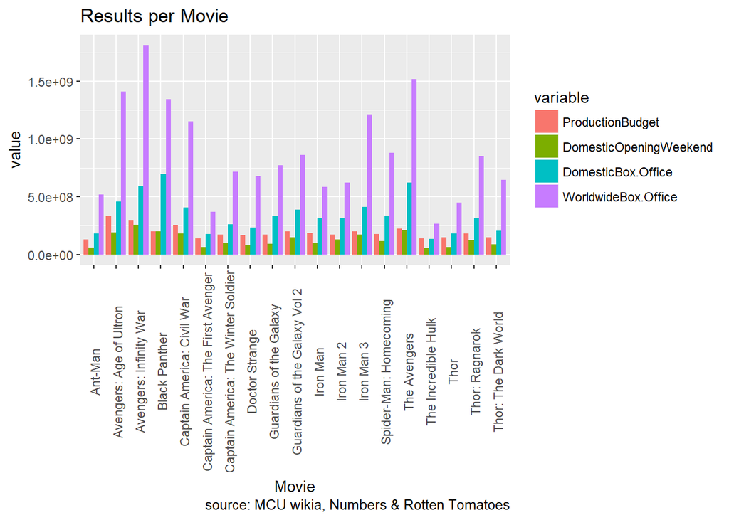

```r
#Data plots

ggplot(data=test_data_long2,
            aes(x=Movie, y=value, fill = variable)) +
  geom_bar(stat = "identity", position=position_dodge())+
  labs(title="Results per Movie",
       caption="source: MCU wikia, Numbers & Rotten Tomatoes") +
  theme(axis.text.x = element_text(angle=90, vjust=0.6))
```

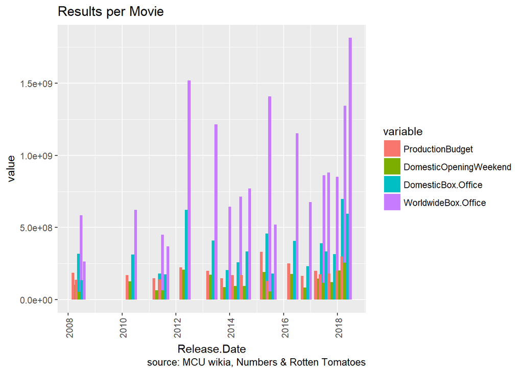

```r
OverallRed3 <- Overall[,2:6]
OverallRed3 <- OverallRed3[1:19,]

test_data_long3 <- melt(OverallRed3, id="Release.Date")

ggplot(data=test_data_long3,
       aes(x=Release.Date, y=value, fill = variable)) +
  geom_bar(stat = "identity", width = 150, position=position_dodge())+
  labs(title="Results per Movie",
       caption="source: MCU wikia, Numbers & Rotten Tomatoes") +
  theme(axis.text.x = element_text(angle=90, vjust=0.6))
```

```r
# ggplot(Overall2, aes(x=Overall2$Release.Date))+
#
#   geom_bar(aes(y = Overall2$WorldwideBox.Office, group = 1, fill = "WorldBoxOffice"),stat="identity", width=100, position=position_dodge())+
#   scale_fill_manual(values=c("grey50"))+
#   geom_line(aes(y = Overall2$Per_Female, group = 1, colour = "Per_Female"))+
#   geom_line(aes(y = Overall2$Per_American, group = 1, colour = "Per_American"))+
#   geom_line(aes(y = Overall2$Tomatoes, group = 1, colour = "Tomatoes"))+
#   xlab("Date")+
#   ylab("Percentage")+
#
#   labs(title="Results per Movie",
#        caption="source: MCU wikia, Numbers & Rotten Tomatoes") +
#   theme(axis.text.x = element_text(angle=90, vjust=0.6))

# ggplot(Overall2, aes(x=Overall2$Movie))+
#
#   geom_line(aes(y = Overall2$Per_Female, group = 1, colour = "Per_Female"))+
#   geom_line(aes(y = Overall2$Per_American, group = 1, colour = "Per_American"))+
#   geom_line(aes(y = Overall2$Tomatoes, group = 1, colour = "Tomatoes"))+
#   geom_point(aes(y = Overall2$WorldwideBox.Office, group = 1, colour = "Box Office Worldwide"))+
#   xlab("Date")+
#   ylab("Percentage")+
#     labs(title="Results per Movie",
#        caption="source: MCU wikia, Numbers & Rotten Tomatoes") +
#   theme(axis.text.x = element_text(angle=90, vjust=0.6))

genderoverall <- genderoverall[rev(order(genderoverall[,3])),]
head(genderoverall)
```

```
##                                   Var1 Freq a$Freq/nrow(Characters)
## 2                                 Male  189             0.726923077
## 1                               Female   69             0.265384615
## 3 Male (masculine programming & voice)    1             0.003846154
```

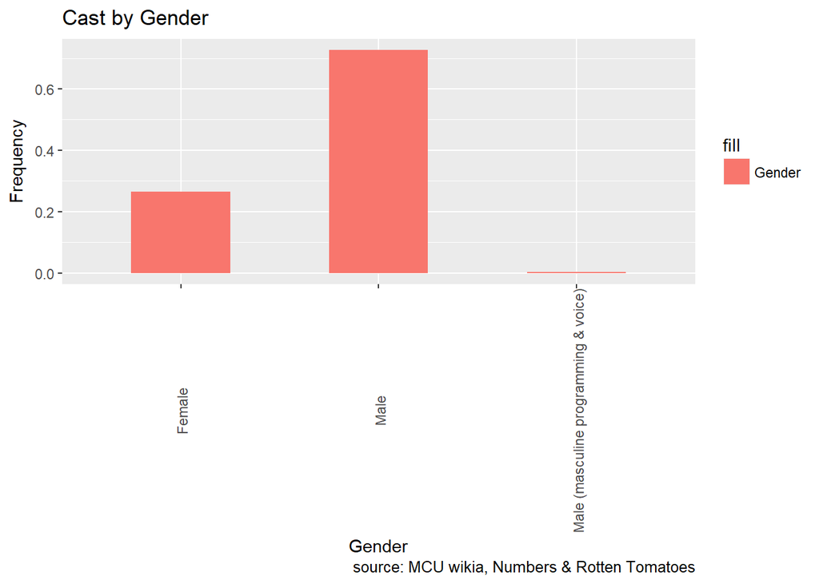

```r
ggplot(genderoverall, aes(x=genderoverall$Var1))+

  geom_bar(aes(y = genderoverall[,3], group = 1, fill = "Gender"),stat="identity", width=.5, position=position_dodge())+
  #geom_point(aes(y = WorldwideBox.Office, group = 1, colour = "Box Office Worldwide"))+
  xlab("Gender")+
  ylab("Frequency")+

    labs(title="Cast by Gender",
       caption="source: MCU wikia, Numbers & Rotten Tomatoes") +
  theme(axis.text.x = element_text(angle=90, vjust=0.6))
```

```r
speciesoverall <- speciesoverall[rev(order(speciesoverall[,3])),]
head(speciesoverall)
```

```
##           Var1 Freq a$Freq/nrow(Characters)
## 12       Human  204             0.784615385
## 3    Asgardian   11             0.042307692
## 10 Frost Giant    5             0.019230769
## 22   Xandarian    3             0.011538462
## 16   Krylorian    3             0.011538462
## 14        Kree    2             0.007692308
```

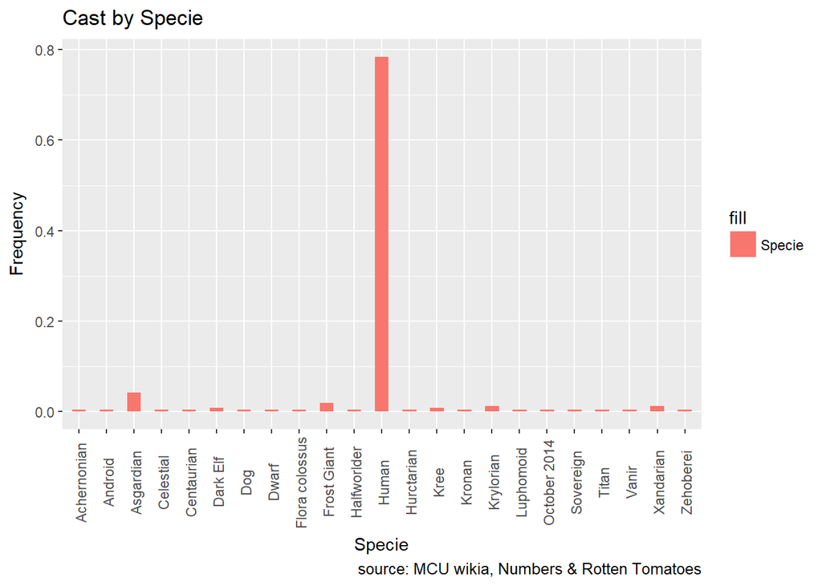

```r
ggplot(speciesoverall, aes(x=speciesoverall$Var1))+

  geom_bar(aes(y = speciesoverall[,3], group = 1, fill = "Specie"),stat="identity", width=.5, position=position_dodge())+
  #geom_point(aes(y = WorldwideBox.Office, group = 1, colour = "Box Office Worldwide"))+
  xlab("Specie")+
  ylab("Frequency")+

  labs(title="Cast by Specie",
       caption="source: MCU wikia, Numbers & Rotten Tomatoes") +
  theme(axis.text.x = element_text(angle=90, vjust=0.6))
```

```r
citizenshipoverall <- citizenshipoverall[rev(order(citizenshipoverall[,3])),]
head(citizenshipoverall)
```

```
##           Var1 Freq a$Freq/nrow(Characters)
## 2     American  145              0.55769231
## 25    Wakandan   11              0.04230769
## 6      British   11              0.04230769
## 3    Asgardian   11              0.04230769
## 14 Nazi German    6              0.02307692
## 1       Afghan    6              0.02307692
```

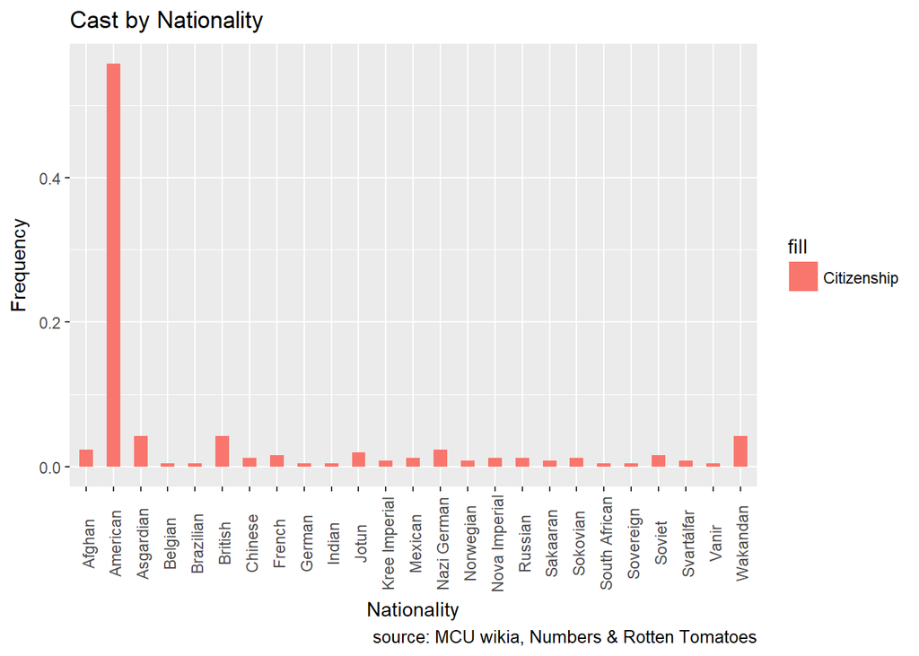

```r
ggplot(citizenshipoverall, aes(x=citizenshipoverall$Var1))+

  geom_bar(aes(y = citizenshipoverall[,3], group = 1, fill = "Citizenship"),stat="identity", width=.5, position=position_dodge())+
  #geom_point(aes(y = WorldwideBox.Office, group = 1, colour = "Box Office Worldwide"))+
  xlab("Nationality")+
  ylab("Frequency")+

  labs(title="Cast by Nationality",
       caption="source: MCU wikia, Numbers & Rotten Tomatoes") +
  theme(axis.text.x = element_text(angle=90, vjust=0.6))
```

```r
head(Characters)
```

```
##         real_name gender citizenship species  age        FileName
## 1           Aaron   Male    American   Human <NA>           Aaron
## 2   Abraham Brown   Male    American   Human <NA>       Abe_Brown
## 3    Emil Blonsky   Male     Russian   Human   47     Abomination
## 4 Abraham Erskine   Male Nazi German   Human   73 Abraham_Erskine
## 5      Abu Bakaar   Male      Afghan   Human <NA>      Abu_Bakaar
## 6  Adam Goldstein   Male    American   Human <NA>  Adam_Goldstein
##            Cast                Character
## 1  D.C. Pierson                    Aaron
## 2 Abraham Attah                Abe Brown
## 3      Tim Roth Emil Blonsky/Abomination
## 4 Stanley Tucci      Dr. Abraham Erskine
## 5 Sayed Badreya               Abu Bakaar
## 6         DJ AM                  Himself
##                                                      Cast_URL
## 1  http://marvelcinematicuniverse.wikia.com/wiki/D.C._Pierson
## 2 http://marvelcinematicuniverse.wikia.com/wiki/Abraham_Attah
## 3      http://marvelcinematicuniverse.wikia.com/wiki/Tim_Roth
## 4 http://marvelcinematicuniverse.wikia.com/wiki/Stanley_Tucci
## 5 http://marvelcinematicuniverse.wikia.com/wiki/Sayed_Badreya
## 6         http://marvelcinematicuniverse.wikia.com/wiki/DJ_AM
##                                                   Character_URL
## 1           http://marvelcinematicuniverse.wikia.com/wiki/Aaron
## 2       http://marvelcinematicuniverse.wikia.com/wiki/Abe_Brown
## 3     http://marvelcinematicuniverse.wikia.com/wiki/Abomination
## 4 http://marvelcinematicuniverse.wikia.com/wiki/Abraham_Erskine
## 5      http://marvelcinematicuniverse.wikia.com/wiki/Abu_Bakaar
## 6  http://marvelcinematicuniverse.wikia.com/wiki/Adam_Goldstein
```

```r
Overall
```

```
##                                  Movie ProductionBudget
## 1                             Iron Man        186000000
## 2                  The Incredible Hulk        137500000
## 3                           Iron Man 2        170000000
## 4                                 Thor        150000000
## 5   Captain America: The First Avenger        140000000
## 6                         The Avengers        225000000
## 7                           Iron Man 3        200000000
## 8                 Thor: The Dark World        150000000
## 9  Captain America: The Winter Soldier        170000000
## 10             Guardians of the Galaxy        170000000
## 11             Avengers: Age of Ultron        330600000
## 12                             Ant-Man        130000000
## 13          Captain America: Civil War        250000000
## 14                      Doctor Strange        165000000
```

[output cut: 51 more lines]

```r
#scatter.smooth(x=Overall2$Per_Female, y=Overall2$WorldwideBox.Office, main="Gender ~ BoxOffice")
#scatter.smooth(x=Overall2$Per_American, y=Overall2$WorldwideBox.Office, main="American ~ BoxOffice")
```

```r
# linearMod <- lm(Overall$WorldwideBox.Office ~ Overall$Tomatoes + Overall$Per_Female + Overall$Per_American + Overall$ProductionBudget , data=Overall)  # build linear regression model on full data
# print(linearMod)
# modelSummary <- summary(linearMod)
# modelSummary[["coefficients"]]
# modelSummary[["fstatistic"]]
# modelSummary[["adj.r.squared"]]
```